# Integrative Cardiovascular Disease Risk Prediction Using Clinical and Genetic Data

Sarah Sylvester

## Abstract

Cardiovascular diseases (CVD) are a leading global cause of mortality. Traditional risk assessment models, such as the Framingham Risk Score, rely solely on common clinical factors. This project investigates the hypothesis that incorporating a **Genetic Risk Score** can enhance the accuracy of CVD prediction beyond these traditional factors. We compare a **Clinical-Only Model** with an **Integrative Model** (Clinical + Genetic Risk) and evaluate performance using the Area Under the ROC Curve (AUC).

## 1. Background & Rationale

Cardiovascular disease (CVD) encompasses a range of conditions affecting the heart and blood vessels. Accurate risk prediction is crucial for preventative intervention.

Traditional risk models use readily available clinical variables:

Advancements in genomics suggest that an individual’s inherited genetic makeup contributes significantly to CVD susceptibility. Genetic Risk Scores (GRS) aggregate risk from many single-nucleotide polymorphisms (SNPs). By including a simulated `genetic_risk` score, this project explores the potential added value of genomic information in a predictive framework.

## 2. Data Source and Preparation

The data I used was sourced from the Kaggle **Cardiovascular Disease Dataset**, which contains 70,000 records with clinical risk factors and a binary CVD outcome. The original dataset can be found via a web search for “Kaggle Cardiovascular Disease dataset.”

### 2.1 Data Loading and Cleaning

```
##     age_yrs         gender          ap_hi           ap_lo
##  Min.   :30.00   Female:44719   Min.   : 70.0   Min.   : 45.00
##  1st Qu.:48.00   Male  :23937   1st Qu.:120.0   1st Qu.: 80.00
##  Median :54.00                  Median :120.0   Median : 80.00
##  Mean   :53.29                  Mean   :126.7   Mean   : 81.32
##  3rd Qu.:58.00                  3rd Qu.:140.0   3rd Qu.: 90.00
##  Max.   :65.00                  Max.   :240.0   Max.   :182.00
##        cholesterol              gluc       smoke        alco       active
##  Normal      :51489   Normal      :58376   No :62616   No :64992   No :13500
##  Above_Normal: 9299   Above_Normal: 5065   Yes: 6040   Yes: 3664   Yes:55156
##  High        : 7868   High        : 5215
##
##
##
##  cardio
##  No :34692
##  Yes:33964
##
##
##
##
```

### 2.2 Simulation of Genetic Risk Score (GRS)

```
## 'data.frame':    68656 obs. of  11 variables:
##  $ age_yrs     : num  50 55 52 48 48 60 61 62 48 54 ...
##  $ gender      : Factor w/ 2 levels "Female","Male": 2 1 1 2 1 1 1 2 1 1 ...
##  $ ap_hi       : int  110 140 130 150 100 120 130 130 110 110 ...
##  $ ap_lo       : int  80 90 70 100 60 80 80 90 70 60 ...
##  $ cholesterol : Factor w/ 3 levels "Normal","Above_Normal",..: 1 3 3 1 1 2 3 3 1 1 ...
##  $ gluc        : Factor w/ 3 levels "Normal","Above_Normal",..: 1 1 1 1 1 2 1 3 1 1 ...
##  $ smoke       : Factor w/ 2 levels "No","Yes": 1 1 1 1 1 1 1 1 1 1 ...
##  $ alco        : Factor w/ 2 levels "No","Yes": 1 1 1 1 1 1 1 1 1 1 ...
##  $ active      : Factor w/ 2 levels "No","Yes": 2 2 1 2 1 1 2 2 2 1 ...
##  $ cardio      : Factor w/ 2 levels "No","Yes": 1 2 2 2 1 1 1 2 1 1 ...
##  $ genetic_risk: int  3 3 3 3 1 1 2 0 1 2 ...
```

## 3. Exploratory Data Analysis

### 3.1 Age and Genetic Risk

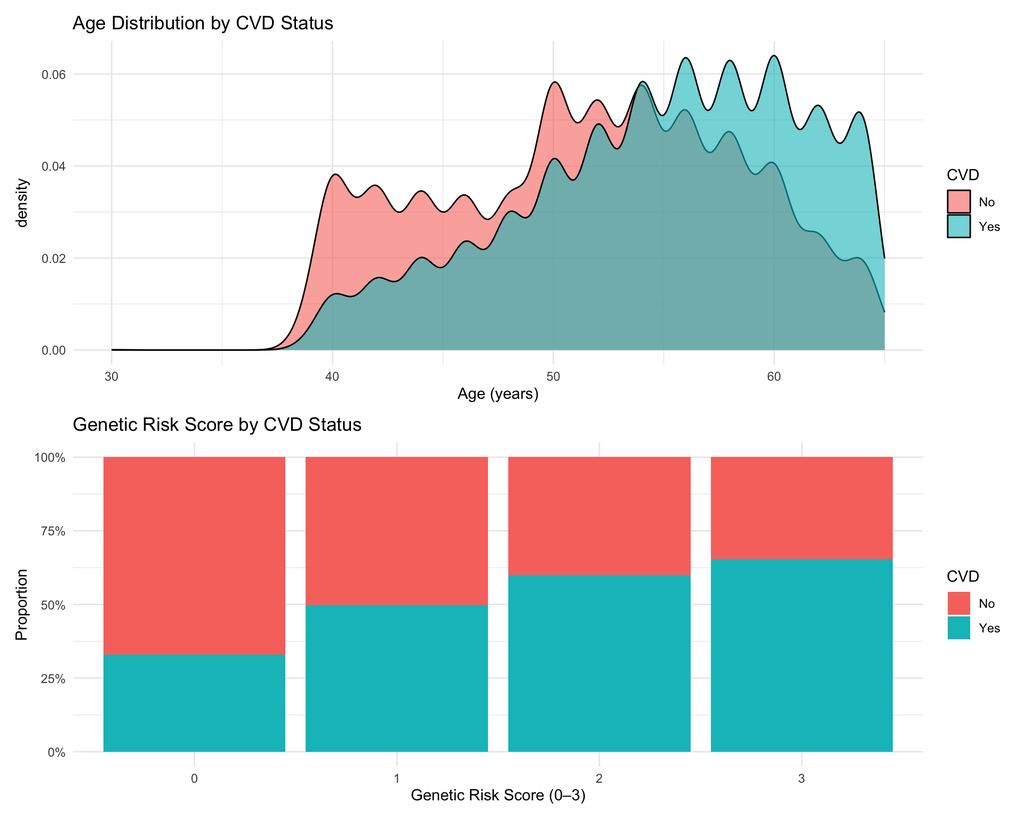

### 3.2 Blood Pressure and Cholesterol

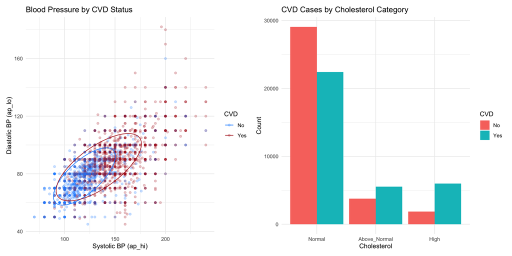

## 4. Modeling and Hypothesis Testing

```
## [1] 0.7897916
```

```
## [1] 0.8083315
```

[figure not shown]

[output not shown]

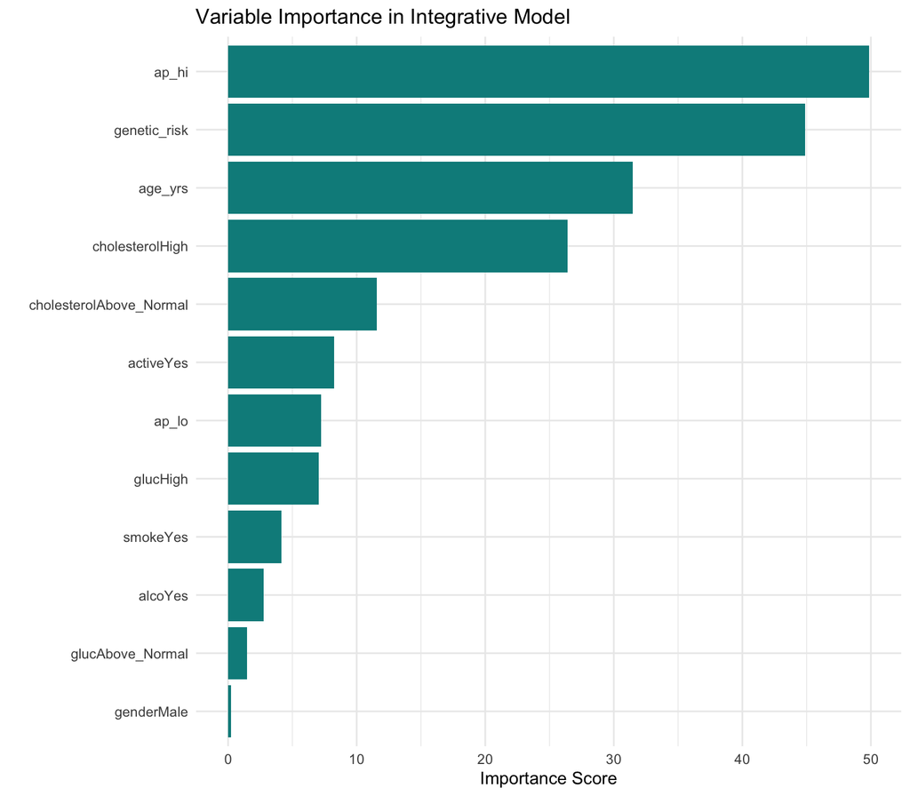